# Interaction & Diagnostic

## Data upload

```r
crime_df =
  read_csv("cdi.csv") %>%
  mutate(
    region = factor(region),
    pop_density = pop / area,
    beds_density = 1000 * beds / pop,
    docs_density = 1000 * docs / pop,
    crm_1000 = 1000 * crimes / pop
  ) %>%
  dplyr::select(-crimes, -id, -area, -pop, -beds, -docs) %>%
  dplyr::select(crm_1000, everything()) %>%
  drop_na()
```

## EDA

```r
crime_state = crime_df %>%
  group_by(state) %>%
  summarize(crime_rate = mean(crm_1000))

crime_state[order(-rank(crime_state$crime_rate)),] %>%
  knitr::kable()
```

| state | crime_rate |
| --- | --- |
| DC | 106.10150 |
| AR | 87.62685 |
| GA | 85.76251 |
| KS | 82.50321 |
| TX | 79.89901 |
| NM | 75.60279 |
| OK | 74.30328 |
| LA | 72.72468 |
| NV | 72.56784 |
| FL | 71.86629 |
| SC | 71.70725 |
| MO | 67.84869 |
| MS | 65.79754 |
| CO | 64.60847 |
| HI | 64.03951 |
| AL | 63.99480 |
| TN | 63.79620 |
| VA | 63.55575 |
| NC | 62.74360 |
| AZ | 62.09854 |
| MI | 60.95516 |
| CA | 60.89497 |
| OR | 59.51382 |
| WA | 58.59162 |
| KY | 58.20736 |
| DE | 57.69290 |
| MD | 55.61703 |
| NE | 55.16350 |
| UT | 53.10673 |
| NJ | 52.32479 |
| IL | 51.12761 |
| NY | 50.76339 |
| WV | 49.35001 |
| WI | 47.81471 |
| ID | 47.14372 |
| RI | 46.09258 |
| MN | 45.99151 |
| SD | 45.43288 |
| IN | 42.53167 |
| OH | 41.37513 |
| ME | 40.02555 |
| MA | 39.11324 |
| VT | 35.96664 |
| CT | 35.37854 |
| MT | 34.20062 |
| ND | 33.05986 |
| NH | 32.65564 |
| PA | 29.45976 |

## Partial ANOVA model select without interaction

```r
#linear regression model with full predictors
fit_no_inte = lm(crm_1000 ~ pop18 +totalinc + poverty + hsgrad + beds_density + docs_density + region + pop_density, data = crime_df)
summary(fit_no_inte)
```

```
##
## Call:
## lm(formula = crm_1000 ~ pop18 + totalinc + poverty + hsgrad +
##     beds_density + docs_density + region + pop_density, data = crime_df)
##
## Residuals:
##     Min      1Q  Median      3Q     Max
## -49.536 -11.453  -0.606  10.089  75.406
##
## Coefficients:
##                Estimate Std. Error t value Pr(>|t|)
## (Intercept)  -2.471e+01  1.601e+01  -1.543 0.123503
## pop18         4.176e-01  2.331e-01   1.792 0.073901 .
## totalinc      2.473e-04  7.250e-05   3.411 0.000708 ***
## poverty       1.607e+00  3.141e-01   5.116 4.71e-07 ***
## hsgrad        3.248e-01  2.025e-01   1.604 0.109452
## beds_density  2.921e+00  7.242e-01   4.034 6.48e-05 ***
## docs_density -5.132e-01  9.134e-01  -0.562 0.574470
## region2       9.001e+00  2.625e+00   3.429 0.000664 ***
## region3       2.586e+01  2.496e+00  10.364  < 2e-16 ***
## region4       2.071e+01  3.074e+00   6.736 5.24e-11 ***
## pop_density   5.145e-03  4.424e-04  11.629  < 2e-16 ***
## ---
## Signif. codes:  0 '***' 0.001 '**' 0.01 '*' 0.05 '.' 0.1 ' ' 1
##
## Residual standard error: 17.97 on 429 degrees of freedom
## Multiple R-squared:  0.5772, Adjusted R-squared:  0.5674
## F-statistic: 58.57 on 10 and 429 DF,  p-value: < 2.2e-16
```

Next using partial ANOVA to test whether large model is superior

### no pop_density

```r
fit_1 = lm(crm_1000 ~ pop18 + totalinc + poverty + hsgrad + beds_density + docs_density + region, data = crime_df)
summary(fit_1)
```

```
##
## Call:
## lm(formula = crm_1000 ~ pop18 + totalinc + poverty + hsgrad +
##     beds_density + docs_density + region, data = crime_df)
##
## Residuals:
##     Min      1Q  Median      3Q     Max
## -73.758 -10.480  -0.863   9.935 217.191
##
## Coefficients:
##                Estimate Std. Error t value Pr(>|t|)
## (Intercept)  -1.430e+01  1.831e+01  -0.781   0.4352
## pop18         6.297e-01  2.662e-01   2.366   0.0184 *
## totalinc      4.760e-04  7.994e-05   5.955 5.42e-09 ***
## poverty       1.844e+00  3.590e-01   5.137 4.25e-07 ***
## hsgrad        1.173e-01  2.311e-01   0.508   0.6119
## beds_density  2.541e+00  8.287e-01   3.067   0.0023 **
## docs_density  1.688e+00  1.024e+00   1.649   0.0998 .
## region2       6.283e+00  2.995e+00   2.098   0.0365 *
## region3       2.172e+01  2.829e+00   7.676 1.12e-13 ***
## region4       1.583e+01  3.489e+00   4.538 7.38e-06 ***
## ---
## Signif. codes:  0 '***' 0.001 '**' 0.01 '*' 0.05 '.' 0.1 ' ' 1
##
## Residual standard error: 20.59 on 430 degrees of freedom
## Multiple R-squared:  0.444,  Adjusted R-squared:  0.4323
## F-statistic: 38.15 on 9 and 430 DF,  p-value: < 2.2e-16
```

```r
# compare nested (small vs large) models
# Ho: smaller model is defensible
anova(fit_1, fit_no_inte)
```

```
## Analysis of Variance Table
##
## Model 1: crm_1000 ~ pop18 + totalinc + poverty + hsgrad + beds_density +
##     docs_density + region
## Model 2: crm_1000 ~ pop18 + totalinc + poverty + hsgrad + beds_density +
##     docs_density + region + pop_density
##   Res.Df    RSS Df Sum of Sq      F    Pr(>F)
## 1    430 182292
## 2    429 138602  1     43690 135.23 < 2.2e-16 ***
## ---
## Signif. codes:  0 '***' 0.001 '**' 0.01 '*' 0.05 '.' 0.1 ' ' 1
```

Reject H0, large model is superior

### no region

```r
fit_2 = lm(crm_1000 ~ pop18 + totalinc + poverty + hsgrad + beds_density + docs_density + pop_density, data = crime_df)
summary(fit_2)
```

```
##
## Call:
## lm(formula = crm_1000 ~ pop18 + totalinc + poverty + hsgrad +
##     beds_density + docs_density + pop_density, data = crime_df)
##
## Residuals:
##    Min     1Q Median     3Q    Max
## -60.71 -12.33  -2.50  12.46  68.43
##
## Coefficients:
##                Estimate Std. Error t value Pr(>|t|)
## (Intercept)  -3.758e+01  1.746e+01  -2.153  0.03190 *
## pop18         5.140e-01  2.572e-01   1.998  0.04631 *
## totalinc      2.523e-04  8.098e-05   3.115  0.00196 **
## poverty       2.798e+00  3.176e-01   8.809  < 2e-16 ***
## hsgrad        5.517e-01  2.137e-01   2.582  0.01015 *
## beds_density  1.805e+00  7.544e-01   2.393  0.01713 *
## docs_density  2.276e-01  9.981e-01   0.228  0.81972
## pop_density   4.433e-03  4.927e-04   8.997  < 2e-16 ***
## ---
## Signif. codes:  0 '***' 0.001 '**' 0.01 '*' 0.05 '.' 0.1 ' ' 1
##
## Residual standard error: 20.28 on 432 degrees of freedom
## Multiple R-squared:  0.4582, Adjusted R-squared:  0.4494
## F-statistic: 52.19 on 7 and 432 DF,  p-value: < 2.2e-16
```

```r
# compare nested (small vs large) models
# Ho: smaller model is defensible
anova(fit_2, fit_no_inte)
```

```
## Analysis of Variance Table
##
## Model 1: crm_1000 ~ pop18 + totalinc + poverty + hsgrad + beds_density +
##     docs_density + pop_density
## Model 2: crm_1000 ~ pop18 + totalinc + poverty + hsgrad + beds_density +
##     docs_density + region + pop_density
##   Res.Df    RSS Df Sum of Sq      F    Pr(>F)
## 1    432 177630
## 2    429 138602  3     39028 40.266 < 2.2e-16 ***
## ---
## Signif. codes:  0 '***' 0.001 '**' 0.01 '*' 0.05 '.' 0.1 ' ' 1
```

Reject H0, large model is superior

### no docs_density

```r
fit_3 = lm(crm_1000 ~  pop18 + totalinc + poverty + hsgrad + beds_density + region + pop_density, data = crime_df)
summary(fit_3)
```

```
##
## Call:
## lm(formula = crm_1000 ~ pop18 + totalinc + poverty + hsgrad +
##     beds_density + region + pop_density, data = crime_df)
##
## Residuals:
##     Min      1Q  Median      3Q     Max
## -49.426 -11.302  -0.614  10.041  75.789
##
## Coefficients:
##                Estimate Std. Error t value Pr(>|t|)
## (Intercept)  -2.218e+01  1.535e+01  -1.445 0.149295
## pop18         3.911e-01  2.281e-01   1.715 0.087128 .
## totalinc      2.406e-04  7.146e-05   3.367 0.000827 ***
## poverty       1.624e+00  3.124e-01   5.197 3.13e-07 ***
## hsgrad        3.007e-01  1.977e-01   1.521 0.129104
## beds_density  2.626e+00  4.976e-01   5.277 2.08e-07 ***
## region2       9.246e+00  2.587e+00   3.574 0.000391 ***
## region3       2.588e+01  2.493e+00  10.378  < 2e-16 ***
## region4       2.056e+01  3.061e+00   6.718 5.85e-11 ***
## pop_density   5.094e-03  4.325e-04  11.777  < 2e-16 ***
## ---
## Signif. codes:  0 '***' 0.001 '**' 0.01 '*' 0.05 '.' 0.1 ' ' 1
##
## Residual standard error: 17.96 on 430 degrees of freedom
## Multiple R-squared:  0.5769, Adjusted R-squared:  0.5681
## F-statistic: 65.15 on 9 and 430 DF,  p-value: < 2.2e-16
```

```r
# compare nested (small vs large) models
# Ho: smaller model is defensible
anova(fit_3, fit_no_inte)
```

```
## Analysis of Variance Table
##
## Model 1: crm_1000 ~ pop18 + totalinc + poverty + hsgrad + beds_density +
##     region + pop_density
## Model 2: crm_1000 ~ pop18 + totalinc + poverty + hsgrad + beds_density +
##     docs_density + region + pop_density
##   Res.Df    RSS Df Sum of Sq      F Pr(>F)
## 1    430 138704
## 2    429 138602  1    102.01 0.3157 0.5745
```

Fail to reject H0, large model is not superior, we should keep the smaller one.

### no beds_density

```r
fit_4 = lm(crm_1000 ~ pop18 + totalinc + poverty + hsgrad + region + pop_density + docs_density, data = crime_df)
summary(fit_4)
```

```
##
## Call:
## lm(formula = crm_1000 ~ pop18 + totalinc + poverty + hsgrad +
##     region + pop_density + docs_density, data = crime_df)
##
## Residuals:
##     Min      1Q  Median      3Q     Max
## -50.950 -11.572  -0.876  10.949  79.338
##
## Coefficients:
##                Estimate Std. Error t value Pr(>|t|)
## (Intercept)  -1.410e+01  1.607e+01  -0.877 0.380758
## pop18         2.357e-01  2.327e-01   1.013 0.311786
## totalinc      2.153e-04  7.333e-05   2.936 0.003508 **
## poverty       2.010e+00  3.031e-01   6.631 1.00e-10 ***
## hsgrad        2.801e-01  2.058e-01   1.361 0.174175
## region2       1.074e+01  2.635e+00   4.078 5.42e-05 ***
## region3       2.566e+01  2.539e+00  10.106  < 2e-16 ***
## region4       1.784e+01  3.044e+00   5.862 9.10e-09 ***
## pop_density   5.065e-03  4.498e-04  11.260  < 2e-16 ***
## docs_density  2.162e+00  6.392e-01   3.382 0.000785 ***
## ---
## Signif. codes:  0 '***' 0.001 '**' 0.01 '*' 0.05 '.' 0.1 ' ' 1
##
## Residual standard error: 18.29 on 430 degrees of freedom
## Multiple R-squared:  0.5612, Adjusted R-squared:  0.552
## F-statistic:  61.1 on 9 and 430 DF,  p-value: < 2.2e-16
```

```r
# compare nested (small vs large) models
# Ho: smaller model is defensible
anova(fit_4, fit_no_inte)
```

```
## Analysis of Variance Table
##
## Model 1: crm_1000 ~ pop18 + totalinc + poverty + hsgrad + region + pop_density +
##     docs_density
## Model 2: crm_1000 ~ pop18 + totalinc + poverty + hsgrad + beds_density +
##     docs_density + region + pop_density
##   Res.Df    RSS Df Sum of Sq      F    Pr(>F)
## 1    430 143860
## 2    429 138602  1    5258.4 16.276 6.483e-05 ***
## ---
## Signif. codes:  0 '***' 0.001 '**' 0.01 '*' 0.05 '.' 0.1 ' ' 1
```

Reject H0, large model is superior

### no hsgrad

```r
fit_5 = lm(crm_1000 ~ pop18 + totalinc + poverty + region + pop_density + docs_density + beds_density, data = crime_df)
summary(fit_5)
```

```
##
## Call:
## lm(formula = crm_1000 ~ pop18 + totalinc + poverty + region +
##     pop_density + docs_density + beds_density, data = crime_df)
##
## Residuals:
##     Min      1Q  Median      3Q     Max
## -50.333 -11.471  -0.716  10.299  73.846
##
## Coefficients:
##                Estimate Std. Error t value Pr(>|t|)
## (Intercept)  -1.2093540  6.4695519  -0.187 0.851804
## pop18         0.5475378  0.2189604   2.501 0.012769 *
## totalinc      0.0002403  0.0000725   3.314 0.000998 ***
## poverty       1.2617950  0.2292289   5.505 6.37e-08 ***
## region2      10.0116174  2.5529898   3.922 0.000102 ***
## region3      26.3126602  2.4843776  10.591  < 2e-16 ***
## region4      22.2663774  2.9224665   7.619 1.64e-13 ***
## pop_density   0.0050826  0.0004415  11.511  < 2e-16 ***
## docs_density -0.2023606  0.8942224  -0.226 0.821077
## beds_density  2.8578704  0.7243940   3.945 9.31e-05 ***
## ---
## Signif. codes:  0 '***' 0.001 '**' 0.01 '*' 0.05 '.' 0.1 ' ' 1
##
## Residual standard error: 18.01 on 430 degrees of freedom
## Multiple R-squared:  0.5747, Adjusted R-squared:  0.5658
## F-statistic: 64.56 on 9 and 430 DF,  p-value: < 2.2e-16
```

```r
# compare nested (small vs large) models
# Ho: smaller model is defensible
anova(fit_5, fit_no_inte)
```

```
## Analysis of Variance Table
##
## Model 1: crm_1000 ~ pop18 + totalinc + poverty + region + pop_density +
##     docs_density + beds_density
## Model 2: crm_1000 ~ pop18 + totalinc + poverty + hsgrad + beds_density +
##     docs_density + region + pop_density
##   Res.Df    RSS Df Sum of Sq      F Pr(>F)
## 1    430 139433
## 2    429 138602  1    831.22 2.5728 0.1095
```

Fail to reject H0, large model is not superior, we should keep the smaller one.

### no poverty

```r
fit_6 = lm(crm_1000 ~ pop18 + totalinc + region + pop_density + docs_density + beds_density + hsgrad, data = crime_df)
summary(fit_6)
```

```
##
## Call:
## lm(formula = crm_1000 ~ pop18 + totalinc + region + pop_density +
##     docs_density + beds_density + hsgrad, data = crime_df)
##
## Residuals:
##     Min      1Q  Median      3Q     Max
## -52.197 -11.670  -0.842  10.300  76.758
##
## Coefficients:
##                Estimate Std. Error t value Pr(>|t|)
## (Intercept)   2.777e+01  1.265e+01   2.195 0.028675 *
## pop18         7.721e-01  2.290e-01   3.372 0.000814 ***
## totalinc      2.260e-04  7.447e-05   3.035 0.002551 **
## region2       1.154e+01  2.652e+00   4.349 1.71e-05 ***
## region3       2.973e+01  2.447e+00  12.147  < 2e-16 ***
## region4       2.749e+01  2.854e+00   9.631  < 2e-16 ***
## pop_density   5.292e-03  4.543e-04  11.650  < 2e-16 ***
## docs_density -9.572e-01  9.355e-01  -1.023 0.306767
## beds_density  4.099e+00  7.064e-01   5.802 1.27e-08 ***
## hsgrad       -3.849e-01  1.518e-01  -2.536 0.011564 *
## ---
## Signif. codes:  0 '***' 0.001 '**' 0.01 '*' 0.05 '.' 0.1 ' ' 1
##
## Residual standard error: 18.49 on 430 degrees of freedom
## Multiple R-squared:  0.5514, Adjusted R-squared:  0.5421
## F-statistic: 58.74 on 9 and 430 DF,  p-value: < 2.2e-16
```

```r
# compare nested (small vs large) models
# Ho: smaller model is defensible
anova(fit_6, fit_no_inte)
```

```
## Analysis of Variance Table
##
## Model 1: crm_1000 ~ pop18 + totalinc + region + pop_density + docs_density +
##     beds_density + hsgrad
## Model 2: crm_1000 ~ pop18 + totalinc + poverty + hsgrad + beds_density +
##     docs_density + region + pop_density
##   Res.Df    RSS Df Sum of Sq      F    Pr(>F)
## 1    430 147059
## 2    429 138602  1    8456.7 26.175 4.712e-07 ***
## ---
## Signif. codes:  0 '***' 0.001 '**' 0.01 '*' 0.05 '.' 0.1 ' ' 1
```

Reject H0, large model is superior

### no totalinc

```r
fit_7 = lm(crm_1000 ~ pop18 + poverty + hsgrad + beds_density + docs_density + region + pop_density, data = crime_df)
summary(fit_7)
```

```
##
## Call:
## lm(formula = crm_1000 ~ pop18 + poverty + hsgrad + beds_density +
##     docs_density + region + pop_density, data = crime_df)
##
## Residuals:
##     Min      1Q  Median      3Q     Max
## -53.252 -11.245  -0.797   9.991  75.301
##
## Coefficients:
##                Estimate Std. Error t value Pr(>|t|)
## (Intercept)  -2.002e+01  1.615e+01  -1.240 0.215822
## pop18         4.302e-01  2.359e-01   1.824 0.068902 .
## poverty       1.545e+00  3.174e-01   4.868 1.58e-06 ***
## hsgrad        2.829e-01  2.046e-01   1.382 0.167557
## beds_density  2.651e+00  7.286e-01   3.638 0.000308 ***
## docs_density -2.649e-03  9.121e-01  -0.003 0.997684
## region2       9.215e+00  2.657e+00   3.469 0.000576 ***
## region3       2.576e+01  2.526e+00  10.198  < 2e-16 ***
## region4       2.189e+01  3.092e+00   7.077 6.01e-12 ***
## pop_density   5.555e-03  4.311e-04  12.884  < 2e-16 ***
## ---
## Signif. codes:  0 '***' 0.001 '**' 0.01 '*' 0.05 '.' 0.1 ' ' 1
##
## Residual standard error: 18.2 on 430 degrees of freedom
## Multiple R-squared:  0.5658, Adjusted R-squared:  0.5567
## F-statistic: 62.25 on 9 and 430 DF,  p-value: < 2.2e-16
```

```r
# compare nested (small vs large) models
# Ho: smaller model is defensible
anova(fit_7, fit_no_inte)
```

```
## Analysis of Variance Table
##
## Model 1: crm_1000 ~ pop18 + poverty + hsgrad + beds_density + docs_density +
##     region + pop_density
## Model 2: crm_1000 ~ pop18 + totalinc + poverty + hsgrad + beds_density +
##     docs_density + region + pop_density
##   Res.Df    RSS Df Sum of Sq      F    Pr(>F)
## 1    430 142362
## 2    429 138602  1    3759.8 11.637 0.0007077 ***
## ---
## Signif. codes:  0 '***' 0.001 '**' 0.01 '*' 0.05 '.' 0.1 ' ' 1
```

Reject H0, large model is superior.

### no pop18

```r
fit_8 = lm(crm_1000 ~ poverty + hsgrad + beds_density + docs_density + region + pop_density + totalinc, data = crime_df)
summary(fit_7)
```

```
##
## Call:
## lm(formula = crm_1000 ~ pop18 + poverty + hsgrad + beds_density +
##     docs_density + region + pop_density, data = crime_df)
##
## Residuals:
##     Min      1Q  Median      3Q     Max
## -53.252 -11.245  -0.797   9.991  75.301
##
## Coefficients:
##                Estimate Std. Error t value Pr(>|t|)
## (Intercept)  -2.002e+01  1.615e+01  -1.240 0.215822
## pop18         4.302e-01  2.359e-01   1.824 0.068902 .
## poverty       1.545e+00  3.174e-01   4.868 1.58e-06 ***
## hsgrad        2.829e-01  2.046e-01   1.382 0.167557
## beds_density  2.651e+00  7.286e-01   3.638 0.000308 ***
## docs_density -2.649e-03  9.121e-01  -0.003 0.997684
## region2       9.215e+00  2.657e+00   3.469 0.000576 ***
## region3       2.576e+01  2.526e+00  10.198  < 2e-16 ***
## region4       2.189e+01  3.092e+00   7.077 6.01e-12 ***
## pop_density   5.555e-03  4.311e-04  12.884  < 2e-16 ***
## ---
## Signif. codes:  0 '***' 0.001 '**' 0.01 '*' 0.05 '.' 0.1 ' ' 1
##
## Residual standard error: 18.2 on 430 degrees of freedom
## Multiple R-squared:  0.5658, Adjusted R-squared:  0.5567
## F-statistic: 62.25 on 9 and 430 DF,  p-value: < 2.2e-16
```

```r
# compare nested (small vs large) models
# Ho: smaller model is defensible
anova(fit_8, fit_no_inte)
```

```
## Analysis of Variance Table
##
## Model 1: crm_1000 ~ poverty + hsgrad + beds_density + docs_density + region +
##     pop_density + totalinc
## Model 2: crm_1000 ~ pop18 + totalinc + poverty + hsgrad + beds_density +
##     docs_density + region + pop_density
##   Res.Df    RSS Df Sum of Sq      F Pr(>F)
## 1    430 139639
## 2    429 138602  1      1037 3.2099 0.0739 .
## ---
## Signif. codes:  0 '***' 0.001 '**' 0.01 '*' 0.05 '.' 0.1 ' ' 1
```

Fail to reject H0, large model is not superior, we should keep the smaller one.

Thus, the fit model would be: `model_selective = lm(crm_1000 ~ pop18 + totalinc + poverty + region + pop_density + docs_density + beds_density, data = crime_df)`

or `model_selective0 = lm(crm_1000 ~ pop18 + totalinc + poverty + region + pop_density + hsgrad + beds_density = crime_df)`

or `model_selective0 = lm(crm_1000 ~ docs_density + totalinc + poverty + region + pop_density + hsgrad + beds_density = crime_df)`

```r
mod_1 = lm(crm_1000 ~ pop18 + totalinc + poverty + region + pop_density + beds_density + docs_density, data = crime_df)
mod_2 = lm(crm_1000 ~ pop18 + totalinc + poverty + region + pop_density + beds_density, data = crime_df)


# compare nested (small vs large) models
# Ho: smaller model is defensible
anova(mod_2, mod_1)
```

```
## Analysis of Variance Table
##
## Model 1: crm_1000 ~ pop18 + totalinc + poverty + region + pop_density +
##     beds_density
## Model 2: crm_1000 ~ pop18 + totalinc + poverty + region + pop_density +
##     beds_density + docs_density
##   Res.Df    RSS Df Sum of Sq      F Pr(>F)
## 1    431 139450
## 2    430 139433  1    16.606 0.0512 0.8211
```

Fail to reject H0, large model is not superior, we should keep the smaller one.

```r
mod_3 = lm(crm_1000 ~ totalinc + poverty + region + pop_density+ beds_density + pop18 + hsgrad, data = crime_df)
mod_4 = lm(crm_1000 ~ pop18 + totalinc + poverty + region + pop_density + beds_density, data = crime_df)


# compare nested (small vs large) models
# Ho: smaller model is defensible
anova(mod_4, mod_3)
```

```
## Analysis of Variance Table
##
## Model 1: crm_1000 ~ pop18 + totalinc + poverty + region + pop_density +
##     beds_density
## Model 2: crm_1000 ~ totalinc + poverty + region + pop_density + beds_density +
##     pop18 + hsgrad
##   Res.Df    RSS Df Sum of Sq      F Pr(>F)
## 1    431 139450
## 2    430 138704  1    745.81 2.3121 0.1291
```

Fail to reject H0, large model is not superior, we should keep the smaller one.

Hence, the model should be: `lm(crm_1000 ~ pop18 + totalinc + poverty + region + pop_density + beds_density, data = crime_df)`

## Information about selective model

```r
model_selective = lm(crm_1000 ~ pop18 + totalinc + poverty + region + pop_density + beds_density, data = crime_df)
summary(model_selective)
```

```
##
## Call:
## lm(formula = crm_1000 ~ pop18 + totalinc + poverty + region +
##     pop_density + beds_density, data = crime_df)
##
## Residuals:
##    Min     1Q Median     3Q    Max
## -50.26 -11.40  -0.73  10.24  74.05
##
## Coefficients:
##                Estimate Std. Error t value Pr(>|t|)
## (Intercept)  -8.850e-01  6.302e+00  -0.140 0.888382
## pop18         5.326e-01  2.085e-01   2.554 0.010993 *
## totalinc      2.377e-04  7.155e-05   3.323 0.000968 ***
## poverty       1.279e+00  2.155e-01   5.936 6.02e-09 ***
## region2       1.008e+01  2.531e+00   3.982 8.01e-05 ***
## region3       2.630e+01  2.481e+00  10.601  < 2e-16 ***
## region4       2.216e+01  2.880e+00   7.694 9.81e-14 ***
## pop_density   5.063e-03  4.327e-04  11.702  < 2e-16 ***
## beds_density  2.738e+00  4.929e-01   5.555 4.88e-08 ***
## ---
## Signif. codes:  0 '***' 0.001 '**' 0.01 '*' 0.05 '.' 0.1 ' ' 1
##
## Residual standard error: 17.99 on 431 degrees of freedom
## Multiple R-squared:  0.5746, Adjusted R-squared:  0.5668
## F-statistic: 72.79 on 8 and 431 DF,  p-value: < 2.2e-16
```

## Potential Interaction

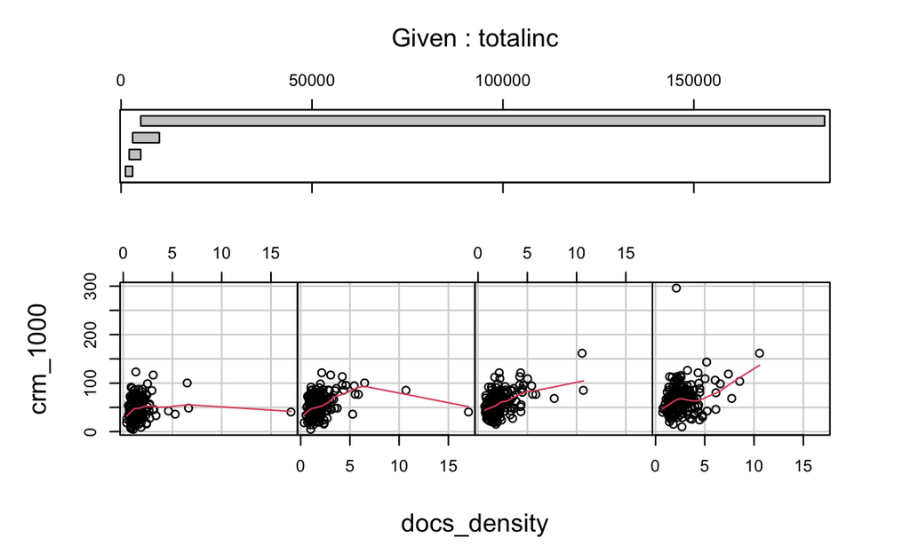

```r
coplot(crm_1000 ~ docs_density | totalinc, data = crime_df,
       number = 4, rows = 1,
       panel = panel.smooth)
```

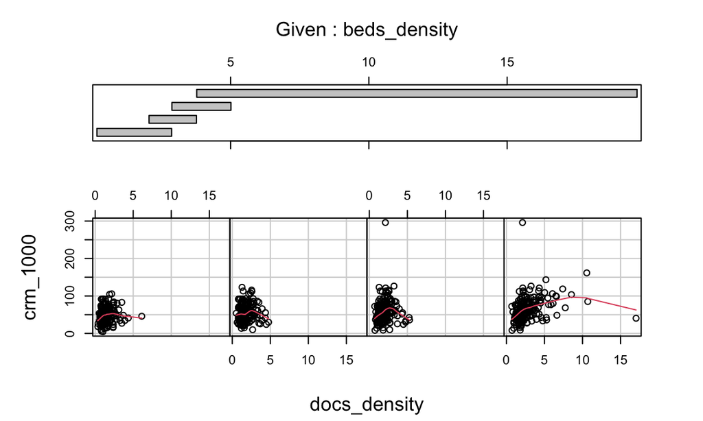

```r
coplot(crm_1000 ~ docs_density | beds_density, data = crime_df,
       number = 4, rows = 1,
       panel = panel.smooth)
```

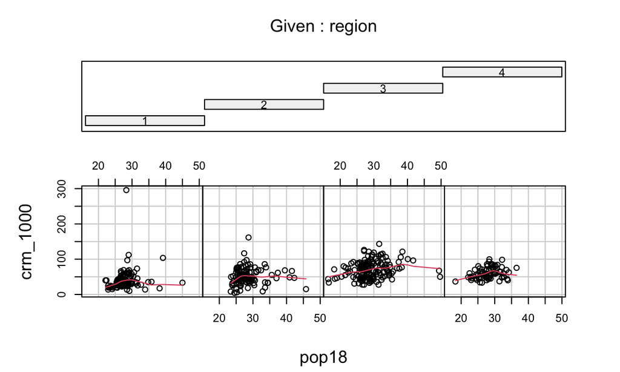

```r
coplot(crm_1000 ~ pop18 | region, data = crime_df,
       number = 4, rows = 1,
       panel = panel.smooth)
```

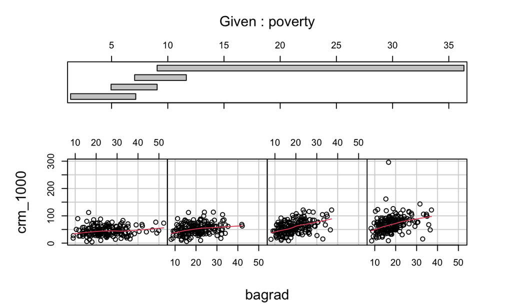

```r
coplot(crm_1000 ~ bagrad | poverty, data = crime_df,
       number = 4, rows = 1,
       panel = panel.smooth)
```

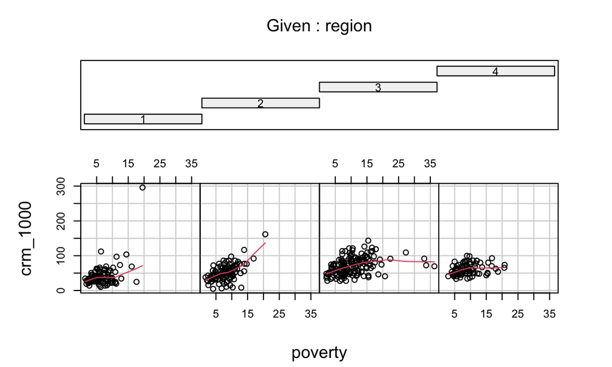

```r
coplot(crm_1000 ~ poverty | region, data = crime_df,
       number = 4, rows = 1,
       panel = panel.smooth)
```

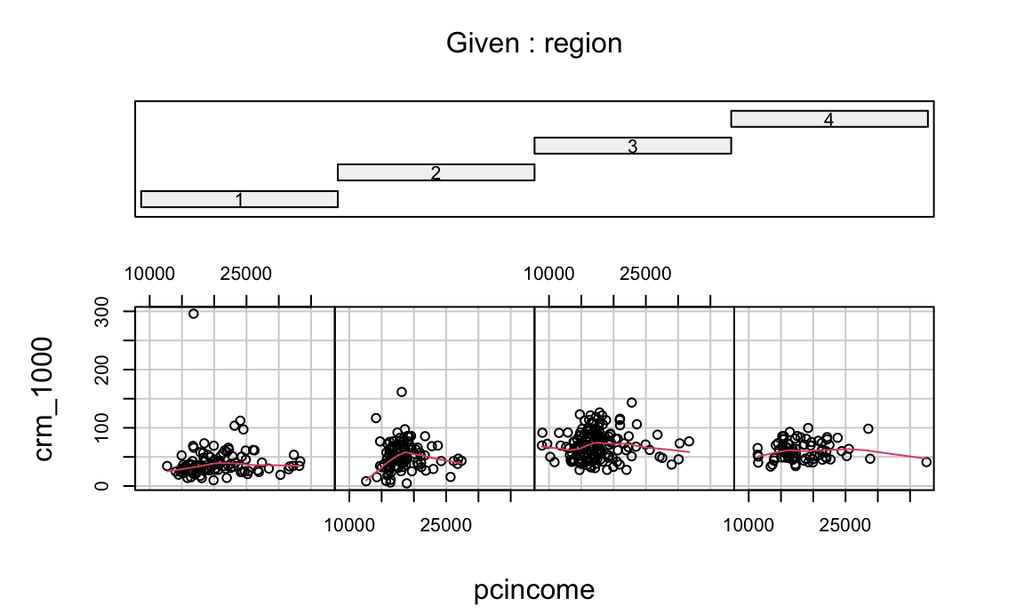

```r
coplot(crm_1000 ~ pcincome | region, data = crime_df,
       number = 4, rows = 1,
       panel = panel.smooth)
```

### model_select

Build model with interaction

```r
select_1 = lm(crm_1000 ~ totalinc + poverty + hsgrad + beds_density + docs_density + region + pop_density + pop18*region + poverty*region + docs_density*totalinc + docs_density*beds_density, data = crime_df)

summary(select_1)
```

```
##
## Call:
## lm(formula = crm_1000 ~ totalinc + poverty + hsgrad + beds_density +
##     docs_density + region + pop_density + pop18 * region + poverty *
##     region + docs_density * totalinc + docs_density * beds_density,
##     data = crime_df)
##
## Residuals:
##     Min      1Q  Median      3Q     Max
## -48.213 -10.773  -0.648   9.364  74.084
##
## Coefficients:
##                             Estimate Std. Error t value Pr(>|t|)
## (Intercept)               -3.307e+01  2.181e+01  -1.516 0.130282
## totalinc                   1.573e-03  2.531e-04   6.214 1.24e-09 ***
## poverty                    1.304e+00  6.385e-01   2.043 0.041690 *
## hsgrad                     2.362e-01  2.091e-01   1.130 0.259303
## beds_density               2.820e+00  7.898e-01   3.571 0.000397 ***
## docs_density               5.285e+00  1.629e+00   3.244 0.001272 **
## region2                    2.043e+01  1.972e+01   1.036 0.300785
## region3                    3.159e+01  1.734e+01   1.821 0.069262 .
## region4                    2.972e+01  2.401e+01   1.238 0.216476
## pop_density                5.504e-03  4.836e-04  11.382  < 2e-16 ***
## pop18                      6.918e-01  5.184e-01   1.335 0.182738
## region2:pop18             -7.555e-01  6.545e-01  -1.154 0.249020
## region3:pop18             -2.500e-01  5.855e-01  -0.427 0.669542
## region4:pop18             -5.324e-01  8.113e-01  -0.656 0.512036
## poverty:region2            1.405e+00  7.619e-01   1.844 0.065859 .
## poverty:region3            1.811e-01  6.394e-01   0.283 0.777138
## poverty:region4            6.095e-01  7.753e-01   0.786 0.432160
## totalinc:docs_density     -5.063e-04  9.116e-05  -5.554 4.95e-08 ***
## beds_density:docs_density -2.549e-01  1.229e-01  -2.074 0.038707 *
## ---
## Signif. codes:  0 '***' 0.001 '**' 0.01 '*' 0.05 '.' 0.1 ' ' 1
##
## Residual standard error: 17.4 on 421 degrees of freedom
## Multiple R-squared:  0.6111, Adjusted R-squared:  0.5945
## F-statistic: 36.76 on 18 and 421 DF,  p-value: < 2.2e-16
```

Test if three interaction term is significant

```r
select_2 = lm(crm_1000 ~ totalinc + poverty + hsgrad + beds_density + docs_density + region + pop_density + pop18*region + poverty*region + docs_density*totalinc, data = crime_df)

anova(select_2, select_1)
```

```
## Analysis of Variance Table
##
## Model 1: crm_1000 ~ totalinc + poverty + hsgrad + beds_density + docs_density +
##     region + pop_density + pop18 * region + poverty * region +
##     docs_density * totalinc
## Model 2: crm_1000 ~ totalinc + poverty + hsgrad + beds_density + docs_density +
##     region + pop_density + pop18 * region + poverty * region +
##     docs_density * totalinc + docs_density * beds_density
##   Res.Df    RSS Df Sum of Sq      F  Pr(>F)
## 1    422 128793
## 2    421 127491  1    1302.3 4.3006 0.03871 *
## ---
## Signif. codes:  0 '***' 0.001 '**' 0.01 '*' 0.05 '.' 0.1 ' ' 1
```

Reject H0

```r
select_3 = lm(crm_1000 ~ totalinc + poverty + hsgrad + beds_density + docs_density + region + pop_density + pop18*region + poverty*region + docs_density*beds_density, data = crime_df)

anova(select_3, select_1)
```

```
## Analysis of Variance Table
##
## Model 1: crm_1000 ~ totalinc + poverty + hsgrad + beds_density + docs_density +
##     region + pop_density + pop18 * region + poverty * region +
##     docs_density * beds_density
## Model 2: crm_1000 ~ totalinc + poverty + hsgrad + beds_density + docs_density +
##     region + pop_density + pop18 * region + poverty * region +
##     docs_density * totalinc + docs_density * beds_density
##   Res.Df    RSS Df Sum of Sq      F    Pr(>F)
## 1    422 136833
## 2    421 127491  1    9341.9 30.849 4.951e-08 ***
## ---
## Signif. codes:  0 '***' 0.001 '**' 0.01 '*' 0.05 '.' 0.1 ' ' 1
```

Reject H0

```r
select_4 = lm(crm_1000 ~ totalinc + poverty + hsgrad + beds_density + docs_density + region + pop_density + pop18*region + docs_density*totalinc + docs_density*beds_density, data = crime_df)

anova(select_4, select_1)
```

```
## Analysis of Variance Table
##
## Model 1: crm_1000 ~ totalinc + poverty + hsgrad + beds_density + docs_density +
##     region + pop_density + pop18 * region + docs_density * totalinc +
##     docs_density * beds_density
## Model 2: crm_1000 ~ totalinc + poverty + hsgrad + beds_density + docs_density +
##     region + pop_density + pop18 * region + poverty * region +
##     docs_density * totalinc + docs_density * beds_density
##   Res.Df    RSS Df Sum of Sq      F Pr(>F)
## 1    424 129046
## 2    421 127491  3    1554.8 1.7115  0.164
```

Accept H0

```r
select_5 = lm(crm_1000 ~ totalinc + poverty + hsgrad + beds_density + docs_density + region + pop_density + docs_density*totalinc + docs_density*beds_density, data = crime_df)

anova(select_5, select_1)
```

```
## Analysis of Variance Table
##
## Model 1: crm_1000 ~ totalinc + poverty + hsgrad + beds_density + docs_density +
##     region + pop_density + docs_density * totalinc + docs_density *
##     beds_density
## Model 2: crm_1000 ~ totalinc + poverty + hsgrad + beds_density + docs_density +
##     region + pop_density + pop18 * region + poverty * region +
##     docs_density * totalinc + docs_density * beds_density
##   Res.Df    RSS Df Sum of Sq      F Pr(>F)
## 1    428 130358
## 2    421 127491  7    2866.6 1.3523 0.2241
```

Accept H0

### model_backward

```r
backward_1 = lm(crm_1000 ~ pop18 + hsgrad + bagrad + poverty + pcincome +
    totalinc + region + pop_density + beds_density + pop18*region + bagrad*poverty + poverty*region + pcincome*region, data = crime_df)
summary(backward_1)
```

```
##
## Call:
## lm(formula = crm_1000 ~ pop18 + hsgrad + bagrad + poverty + pcincome +
##     totalinc + region + pop_density + beds_density + pop18 *
##     region + bagrad * poverty + poverty * region + pcincome *
##     region, data = crime_df)
##
## Residuals:
##     Min      1Q  Median      3Q     Max
## -43.871 -11.038   0.186   9.946  83.144
##
## Coefficients:
##                    Estimate Std. Error t value Pr(>|t|)
## (Intercept)      -4.908e+01  3.205e+01  -1.532 0.126384
## pop18             9.629e-01  5.583e-01   1.725 0.085309 .
## hsgrad            3.350e-01  2.783e-01   1.204 0.229341
## bagrad           -1.282e+00  3.352e-01  -3.824 0.000151 ***
## poverty           3.258e-01  9.473e-01   0.344 0.731067
## pcincome          1.711e-03  6.268e-04   2.730 0.006596 **
## totalinc          1.355e-04  7.789e-05   1.739 0.082723 .
## region2          -1.276e+01  3.029e+01  -0.421 0.673861
## region3           3.692e+01  2.491e+01   1.482 0.139107
## region4           6.440e+01  3.105e+01   2.074 0.038688 *
## pop_density       4.629e-03  5.234e-04   8.844  < 2e-16 ***
## beds_density      1.366e+00  5.635e-01   2.424 0.015791 *
## pop18:region2    -4.442e-01  6.642e-01  -0.669 0.503951
## pop18:region3    -2.772e-01  5.926e-01  -0.468 0.640221
## pop18:region4    -4.829e-01  8.234e-01  -0.586 0.557882
## bagrad:poverty    1.203e-01  2.944e-02   4.087 5.23e-05 ***
## poverty:region2   1.489e+00  9.707e-01   1.534 0.125670
## poverty:region3  -3.038e-01  8.479e-01  -0.358 0.720256
## poverty:region4  -7.835e-01  1.030e+00  -0.761 0.447353
## pcincome:region2  1.301e-03  8.928e-04   1.457 0.145920
## pcincome:region3 -1.518e-05  6.838e-04  -0.022 0.982294
## pcincome:region4 -1.287e-03  7.921e-04  -1.625 0.104898
## ---
## Signif. codes:  0 '***' 0.001 '**' 0.01 '*' 0.05 '.' 0.1 ' ' 1
##
## Residual standard error: 17.53 on 418 degrees of freedom
## Multiple R-squared:  0.608,  Adjusted R-squared:  0.5883
## F-statistic: 30.88 on 21 and 418 DF,  p-value: < 2.2e-16
```

Test if interaction term is significant

```r
backward_2 = lm(crm_1000 ~ pop18 + hsgrad + bagrad + poverty + pcincome +
    totalinc + region + pop_density + beds_density + bagrad*poverty + poverty*region + pcincome*region, data = crime_df)

anova(backward_2, backward_1)
```

```
## Analysis of Variance Table
##
## Model 1: crm_1000 ~ pop18 + hsgrad + bagrad + poverty + pcincome + totalinc +
##     region + pop_density + beds_density + bagrad * poverty +
##     poverty * region + pcincome * region
## Model 2: crm_1000 ~ pop18 + hsgrad + bagrad + poverty + pcincome + totalinc +
##     region + pop_density + beds_density + pop18 * region + bagrad *
##     poverty + poverty * region + pcincome * region
##   Res.Df    RSS Df Sum of Sq      F Pr(>F)
## 1    421 128670
## 2    418 128502  3     167.3 0.1814  0.909
```

Not Reject H0

```r
backward_3 = lm(crm_1000 ~ pop18 + hsgrad + bagrad + poverty + pcincome +
    totalinc + region + pop_density + beds_density + poverty*region + pcincome*region, data = crime_df)

anova(backward_3, backward_1)
```

```
## Analysis of Variance Table
##
## Model 1: crm_1000 ~ pop18 + hsgrad + bagrad + poverty + pcincome + totalinc +
##     region + pop_density + beds_density + poverty * region +
##     pcincome * region
## Model 2: crm_1000 ~ pop18 + hsgrad + bagrad + poverty + pcincome + totalinc +
##     region + pop_density + beds_density + pop18 * region + bagrad *
##     poverty + poverty * region + pcincome * region
##   Res.Df    RSS Df Sum of Sq     F   Pr(>F)
## 1    422 133761
## 2    418 128502  4    5258.2 4.276 0.002111 **
## ---
## Signif. codes:  0 '***' 0.001 '**' 0.01 '*' 0.05 '.' 0.1 ' ' 1
```

Reject H0

```r
backward_4 = lm(crm_1000 ~ pop18 + hsgrad + bagrad + poverty + pcincome +
    totalinc + region + pop_density + beds_density + bagrad*poverty + pcincome*region, data = crime_df)
anova(backward_4, backward_1)
```

```
## Analysis of Variance Table
##
## Model 1: crm_1000 ~ pop18 + hsgrad + bagrad + poverty + pcincome + totalinc +
##     region + pop_density + beds_density + bagrad * poverty +
##     pcincome * region
## Model 2: crm_1000 ~ pop18 + hsgrad + bagrad + poverty + pcincome + totalinc +
##     region + pop_density + beds_density + pop18 * region + bagrad *
##     poverty + poverty * region + pcincome * region
##   Res.Df    RSS Df Sum of Sq      F Pr(>F)
## 1    424 131177
## 2    418 128502  6    2674.5 1.4499 0.1942
```

```r
backward_5 = lm(crm_1000 ~ pop18 + hsgrad + bagrad + poverty + pcincome +
    totalinc + region + pop_density + beds_density + bagrad*poverty + poverty*region, data = crime_df)

anova(backward_5, backward_1)
```

```
## Analysis of Variance Table
##
## Model 1: crm_1000 ~ pop18 + hsgrad + bagrad + poverty + pcincome + totalinc +
##     region + pop_density + beds_density + bagrad * poverty +
##     poverty * region
## Model 2: crm_1000 ~ pop18 + hsgrad + bagrad + poverty + pcincome + totalinc +
##     region + pop_density + beds_density + pop18 * region + bagrad *
##     poverty + poverty * region + pcincome * region
##   Res.Df    RSS Df Sum of Sq      F Pr(>F)
## 1    424 130971
## 2    418 128502  6    2468.5 1.3383 0.2387
```

Accept H0

## Candidate models

```r
model_1 = lm(crm_1000 ~ totalinc + poverty + hsgrad + beds_density + docs_density + region + pop_density + docs_density*totalinc + docs_density*beds_density, data = crime_df)

model_2 = lm(crm_1000 ~ pop18 + hsgrad + bagrad + poverty + pcincome +
    totalinc + region + pop_density + beds_density + bagrad*poverty + poverty*region, data = crime_df)

model_3 = lm(crm_1000 ~ pop18 + hsgrad + bagrad + poverty + pcincome +
    totalinc + region + pop_density + beds_density + bagrad*poverty, data = crime_df)
```

## Diagnostic: Boxcox

```r
#model 1
bc <- boxcox(model_1, lambda = seq(-5, 5, by = 0.25))
```

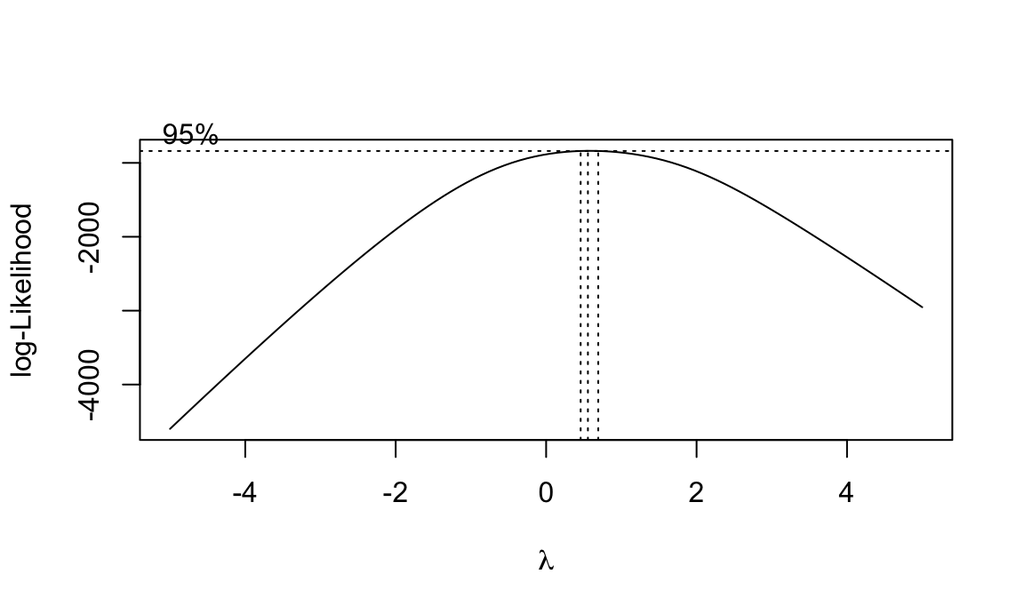

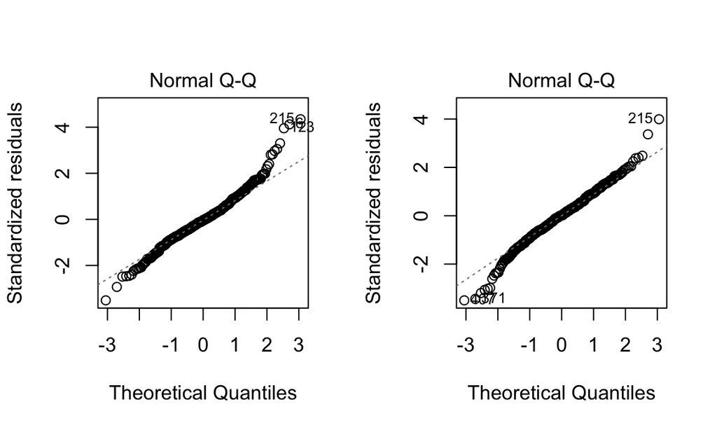

```r
lambda <- bc$x[which.max(bc$y)]
#choose power 1/2

crime_df$crm.bc <- crime_df$crm_1000^(1/2)
model_bc1 = lm(crm.bc ~ totalinc + poverty + hsgrad + beds_density + docs_density + region + pop_density + docs_density*totalinc + docs_density*beds_density, data = crime_df)

par(mfrow = c(1,2))
plot(model_1, which = 2)
plot(model_bc1, which = 2)
```

```r
summary(model_1)
```

```
##
## Call:
## lm(formula = crm_1000 ~ totalinc + poverty + hsgrad + beds_density +
##     docs_density + region + pop_density + docs_density * totalinc +
##     docs_density * beds_density, data = crime_df)
##
## Residuals:
##     Min      1Q  Median      3Q     Max
## -42.407 -10.405  -0.690   9.329  75.303
##
## Coefficients:
##                             Estimate Std. Error t value Pr(>|t|)
## (Intercept)               -2.268e+01  1.560e+01  -1.454 0.146661
## totalinc                   1.564e-03  2.514e-04   6.221 1.18e-09 ***
## poverty                    1.776e+00  2.933e-01   6.056 3.05e-09 ***
## hsgrad                     3.142e-01  1.901e-01   1.653 0.099058 .
## beds_density               2.777e+00  7.488e-01   3.708 0.000236 ***
## docs_density               5.085e+00  1.582e+00   3.215 0.001404 **
## region2                    9.514e+00  2.595e+00   3.667 0.000277 ***
## region3                    2.533e+01  2.428e+00  10.433  < 2e-16 ***
## region4                    1.905e+01  2.997e+00   6.357 5.27e-10 ***
## pop_density                5.516e-03  4.326e-04  12.752  < 2e-16 ***
## totalinc:docs_density     -4.985e-04  9.077e-05  -5.492 6.81e-08 ***
## beds_density:docs_density -2.216e-01  1.222e-01  -1.814 0.070382 .
## ---
## Signif. codes:  0 '***' 0.001 '**' 0.01 '*' 0.05 '.' 0.1 ' ' 1
##
## Residual standard error: 17.45 on 428 degrees of freedom
## Multiple R-squared:  0.6024, Adjusted R-squared:  0.5922
## F-statistic: 58.95 on 11 and 428 DF,  p-value: < 2.2e-16
```

```r
summary(model_bc1)
```

```
##
## Call:
## lm(formula = crm.bc ~ totalinc + poverty + hsgrad + beds_density +
##     docs_density + region + pop_density + docs_density * totalinc +
##     docs_density * beds_density, data = crime_df)
##
## Residuals:
##     Min      1Q  Median      3Q     Max
## -4.0284 -0.6795  0.0208  0.6770  4.5990
##
## Coefficients:
##                             Estimate Std. Error t value Pr(>|t|)
## (Intercept)                2.476e+00  1.037e+00   2.387 0.017421 *
## totalinc                   9.437e-05  1.672e-05   5.646 3.00e-08 ***
## poverty                    1.025e-01  1.950e-02   5.255 2.33e-07 ***
## hsgrad                     1.478e-02  1.264e-02   1.170 0.242826
## beds_density               2.066e-01  4.979e-02   4.150 4.01e-05 ***
## docs_density               4.120e-01  1.052e-01   3.918 0.000104 ***
## region2                    7.327e-01  1.725e-01   4.247 2.66e-05 ***
## region3                    1.826e+00  1.614e-01  11.313  < 2e-16 ***
## region4                    1.514e+00  1.993e-01   7.599 1.89e-13 ***
## pop_density                2.594e-04  2.876e-05   9.021  < 2e-16 ***
## totalinc:docs_density     -2.919e-05  6.035e-06  -4.838 1.84e-06 ***
## beds_density:docs_density -2.291e-02  8.123e-03  -2.821 0.005014 **
## ---
## Signif. codes:  0 '***' 0.001 '**' 0.01 '*' 0.05 '.' 0.1 ' ' 1
##
## Residual standard error: 1.16 on 428 degrees of freedom
## Multiple R-squared:  0.5653, Adjusted R-squared:  0.5541
## F-statistic:  50.6 on 11 and 428 DF,  p-value: < 2.2e-16
```

```r
#model 2
bc <- boxcox(model_2, lambda = seq(-5, 5, by = 0.25))
```

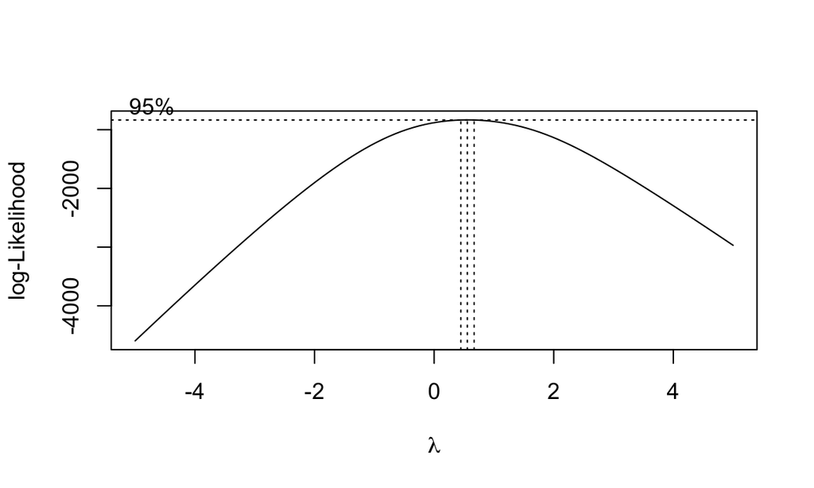

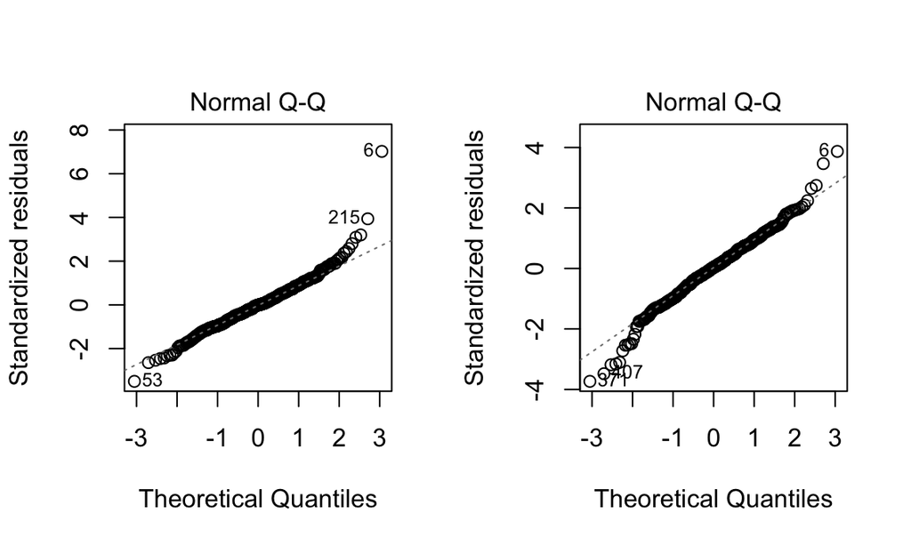

```r
lambda <- bc$x[which.max(bc$y)]
#choose power 1/2

crime_df$crm.bc <- crime_df$crm_1000^(1/2)
model_bc2 = lm(crm.bc ~ pop18 + hsgrad + bagrad + poverty + pcincome +
    totalinc + region + pop_density + beds_density + bagrad*poverty + poverty*region, data = crime_df)

par(mfrow = c(1,2))
plot(model_2, which = 2)
plot(model_bc2, which = 2)
```

```r
summary(model_2)
```

```
##
## Call:
## lm(formula = crm_1000 ~ pop18 + hsgrad + bagrad + poverty + pcincome +
##     totalinc + region + pop_density + beds_density + bagrad *
##     poverty + poverty * region, data = crime_df)
##
## Residuals:
##     Min      1Q  Median      3Q     Max
## -56.314 -10.741  -0.078  10.028  81.334
##
## Coefficients:
##                   Estimate Std. Error t value Pr(>|t|)
## (Intercept)     -4.118e+01  2.616e+01  -1.574 0.116272
## pop18            5.348e-01  2.896e-01   1.846 0.065534 .
## hsgrad           4.387e-01  2.691e-01   1.630 0.103775
## bagrad          -1.191e+00  3.238e-01  -3.678 0.000265 ***
## poverty          3.208e-01  8.679e-01   0.370 0.711867
## pcincome         1.435e-03  4.877e-04   2.942 0.003442 **
## totalinc         1.488e-04  7.591e-05   1.960 0.050704 .
## region2          1.619e+00  6.228e+00   0.260 0.795079
## region3          2.789e+01  5.477e+00   5.092 5.34e-07 ***
## region4          1.776e+01  6.936e+00   2.560 0.010806 *
## pop_density      4.744e-03  5.098e-04   9.306  < 2e-16 ***
## beds_density     1.430e+00  5.569e-01   2.568 0.010561 *
## bagrad:poverty   1.147e-01  2.935e-02   3.906 0.000109 ***
## poverty:region2  1.050e+00  7.913e-01   1.327 0.185117
## poverty:region3 -1.900e-01  6.832e-01  -0.278 0.781121
## poverty:region4  2.123e-01  8.040e-01   0.264 0.791806
## ---
## Signif. codes:  0 '***' 0.001 '**' 0.01 '*' 0.05 '.' 0.1 ' ' 1
##
## Residual standard error: 17.58 on 424 degrees of freedom
## Multiple R-squared:  0.6005, Adjusted R-squared:  0.5864
## F-statistic: 42.49 on 15 and 424 DF,  p-value: < 2.2e-16
```

```r
summary(model_bc2)
```

```
##
## Call:
## lm(formula = crm.bc ~ pop18 + hsgrad + bagrad + poverty + pcincome +
##     totalinc + region + pop_density + beds_density + bagrad *
##     poverty + poverty * region, data = crime_df)
##
## Residuals:
##     Min      1Q  Median      3Q     Max
## -4.2670 -0.6815  0.0434  0.7399  3.9237
##
## Coefficients:
##                   Estimate Std. Error t value Pr(>|t|)
## (Intercept)      3.842e-01  1.719e+00   0.223 0.823269
## pop18            4.803e-02  1.903e-02   2.524 0.011976 *
## hsgrad           2.268e-02  1.768e-02   1.283 0.200199
## bagrad          -8.049e-02  2.127e-02  -3.783 0.000177 ***
## poverty          3.204e-02  5.703e-02   0.562 0.574536
## pcincome         1.235e-04  3.205e-05   3.853 0.000135 ***
## totalinc         1.042e-05  4.988e-06   2.090 0.037244 *
## region2          2.584e-01  4.092e-01   0.631 0.528054
## region3          2.105e+00  3.599e-01   5.848 9.96e-09 ***
## region4          1.466e+00  4.557e-01   3.216 0.001397 **
## pop_density      2.003e-04  3.350e-05   5.978 4.80e-09 ***
## beds_density     1.067e-01  3.659e-02   2.915 0.003743 **
## bagrad:poverty   7.414e-03  1.929e-03   3.844 0.000140 ***
## poverty:region2  5.975e-02  5.199e-02   1.149 0.251118
## poverty:region3 -2.781e-02  4.490e-02  -0.620 0.535907
## poverty:region4  7.122e-03  5.283e-02   0.135 0.892819
## ---
## Signif. codes:  0 '***' 0.001 '**' 0.01 '*' 0.05 '.' 0.1 ' ' 1
##
## Residual standard error: 1.155 on 424 degrees of freedom
## Multiple R-squared:  0.5734, Adjusted R-squared:  0.5583
## F-statistic: 37.99 on 15 and 424 DF,  p-value: < 2.2e-16
```

```r
#model 3
bc <- boxcox(model_3, lambda = seq(-5, 5, by = 0.25))
```

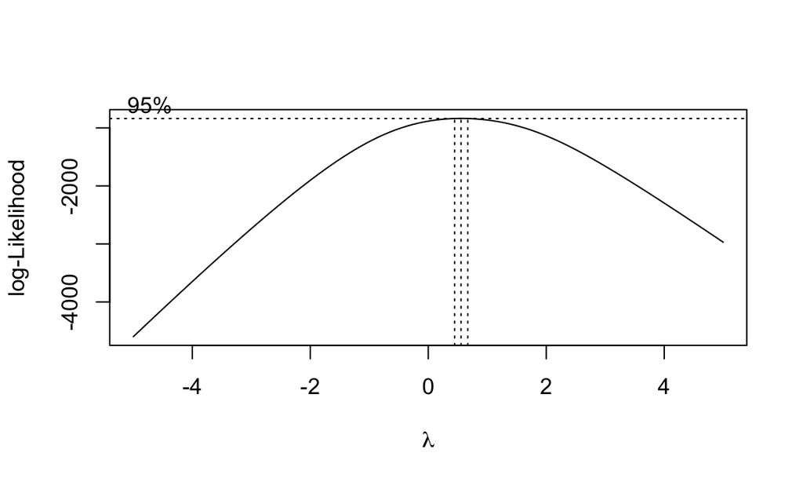

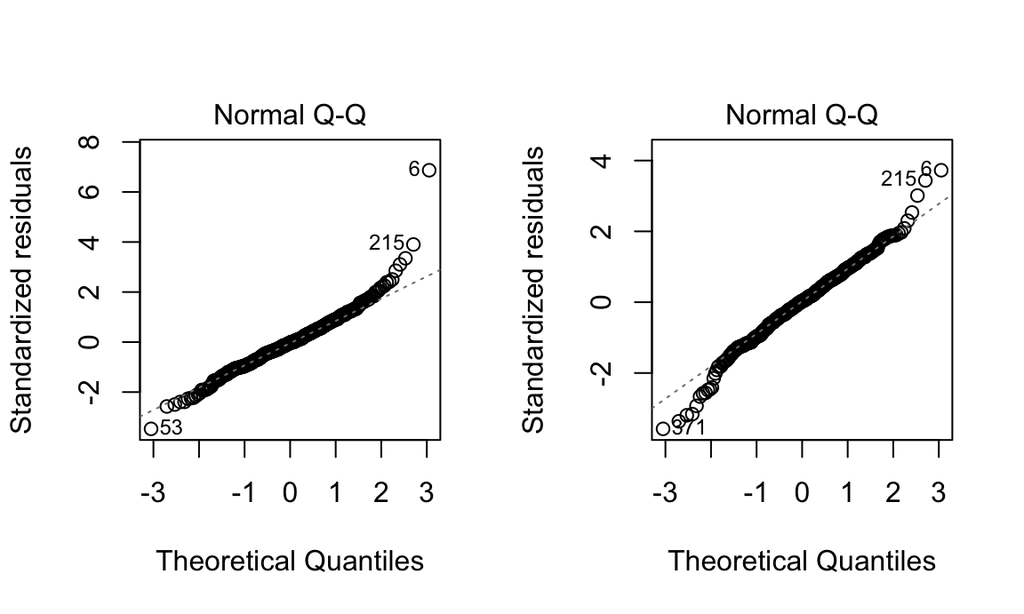

```r
lambda <- bc$x[which.max(bc$y)]
#choose power 1/2

crime_df$crm.bc <- crime_df$crm_1000^(1/2)
model_bc3 = lm(crm.bc ~ pop18 + hsgrad + bagrad + poverty + pcincome +
    totalinc + region + pop_density + beds_density + bagrad*poverty, data = crime_df)

par(mfrow = c(1,2))
plot(model_3, which = 2)
plot(model_bc3, which = 2)
```

```r
summary(model_3)
```

```
##
## Call:
## lm(formula = crm_1000 ~ pop18 + hsgrad + bagrad + poverty + pcincome +
##     totalinc + region + pop_density + beds_density + bagrad *
##     poverty, data = crime_df)
##
## Residuals:
##     Min      1Q  Median      3Q     Max
## -56.571 -11.067  -0.705   9.708  79.879
##
## Coefficients:
##                  Estimate Std. Error t value Pr(>|t|)
## (Intercept)    -4.144e+01  2.514e+01  -1.648 0.100007
## pop18           5.621e-01  2.889e-01   1.946 0.052353 .
## hsgrad          4.302e-01  2.630e-01   1.636 0.102604
## bagrad         -1.219e+00  3.227e-01  -3.779 0.000180 ***
## poverty         3.589e-01  5.735e-01   0.626 0.531788
## pcincome        1.432e-03  4.724e-04   3.032 0.002573 **
## totalinc        1.593e-04  7.582e-05   2.101 0.036264 *
## region2         9.747e+00  2.632e+00   3.703 0.000241 ***
## region3         2.585e+01  2.516e+00  10.276  < 2e-16 ***
## region4         2.004e+01  3.050e+00   6.569 1.48e-10 ***
## pop_density     4.775e-03  4.447e-04  10.739  < 2e-16 ***
## beds_density    1.683e+00  5.397e-01   3.118 0.001946 **
## bagrad:poverty  1.111e-01  2.935e-02   3.787 0.000174 ***
## ---
## Signif. codes:  0 '***' 0.001 '**' 0.01 '*' 0.05 '.' 0.1 ' ' 1
##
## Residual standard error: 17.61 on 427 degrees of freedom
## Multiple R-squared:  0.5962, Adjusted R-squared:  0.5849
## F-statistic: 52.55 on 12 and 427 DF,  p-value: < 2.2e-16
```

```r
summary(model_bc3)
```

```
##
## Call:
## lm(formula = crm.bc ~ pop18 + hsgrad + bagrad + poverty + pcincome +
##     totalinc + region + pop_density + beds_density + bagrad *
##     poverty, data = crime_df)
##
## Residuals:
##     Min      1Q  Median      3Q     Max
## -4.1095 -0.6713  0.0352  0.7383  3.9049
##
## Coefficients:
##                  Estimate Std. Error t value Pr(>|t|)
## (Intercept)     5.333e-01  1.653e+00   0.323 0.747190
## pop18           4.948e-02  1.900e-02   2.604 0.009541 **
## hsgrad          2.189e-02  1.730e-02   1.266 0.206323
## bagrad         -8.251e-02  2.122e-02  -3.888 0.000117 ***
## poverty         2.101e-02  3.772e-02   0.557 0.577762
## pcincome        1.205e-04  3.107e-05   3.879 0.000122 ***
## totalinc        1.116e-05  4.986e-06   2.237 0.025775 *
## region2         7.349e-01  1.731e-01   4.245 2.68e-05 ***
## region3         1.857e+00  1.655e-01  11.225  < 2e-16 ***
## region4         1.588e+00  2.006e-01   7.914 2.16e-14 ***
## pop_density     2.074e-04  2.925e-05   7.093 5.49e-12 ***
## beds_density    1.242e-01  3.550e-02   3.499 0.000515 ***
## bagrad:poverty  7.186e-03  1.930e-03   3.723 0.000223 ***
## ---
## Signif. codes:  0 '***' 0.001 '**' 0.01 '*' 0.05 '.' 0.1 ' ' 1
##
## Residual standard error: 1.158 on 427 degrees of freedom
## Multiple R-squared:  0.5681, Adjusted R-squared:  0.5559
## F-statistic:  46.8 on 12 and 427 DF,  p-value: < 2.2e-16
```